## BLAST

- format 6중 원하는 서열만 골라서 Table을 구성 하였음.
- slen을 통하여 alignment length를 구할수 있게 하였음
- max_target_seqs를 3으로 설정하여 최대 3개의 CDS hit까지 확인 가능 하도록 하였음.

`blastn -query merge.fasta -db /home/kun/Raw_data/DB/TCC_cluster/TCC2 -outfmt "6 qseqid sseqid length mismatch gapopen qstart qend sstart send bitscore slen qlen" -task blastn -max_hsps 1 -max_target_seqs 3 > test.txt`

# R

```r
library(readxl)
library(Biostrings)
library(ggplot2)
library(tidyverse)
library(gridExtra)

path = "C:\\Users\\user\\task\\barcode06\\filter\\blast\\test.txt"
query = "C:\\Users\\user\\task\\barcode06\\filter\\blast\\merge.fasta"
db = "C:\\users\\user\\task\\Raw_data\\DB\\TCC_cluster\\TCC2.fasta"
db_seq = readDNAStringSet(db, format = "fasta")
db_len = width(db_seq)

blast_header <- c("qseqid", "sseqid", "length", "mismatch", "gapopen", "qstart", "qend", "sstart",
            "send", "bitscore", "slen", "qlen")
```

header는 꼭 필요하진 않지만 기존의 header를 그대로 이용 하였음.

## Data Frame 생성

```r
df <- read.csv(path, header=FALSE, sep ='\t')
names(df) <- blast_header
df <- df[df$qlen<8000,]
str(df)
```

```
## 'data.frame':    29222 obs. of  12 variables:
##  $ qseqid  : chr  "aa02aac7-749c-406a-9303-754d671a7f6f" "aa02aac7-749c-406a-9303-754d671a7f6f" "cfd11d51-5a71-4f5c-81c5-f6269617bf86" "cfd11d51-5a71-4f5c-81c5-f6269617bf86" ...
##  $ sseqid  : chr  "B" "A1" "B" "A1" ...
##  $ length  : int  397 11 834 11 1018 11 464 319 11 703 ...
##  $ mismatch: int  9 0 23 0 36 0 9 7 0 21 ...
##  $ gapopen : int  9 0 17 0 29 0 12 10 0 17 ...
##  $ qstart  : int  20 83 1 38 203 327 505 1 122 2 ...
##  $ qend    : int  403 93 816 48 1184 337 953 307 132 691 ...
##  $ sstart  : int  948 432 132 128 2 179 465 315 138 694 ...
##  $ send    : int  557 422 948 138 1011 189 9 1 128 2 ...
##  $ bitscore: num  571 21.1 1198 21.1 1384 ...
##  $ slen    : int  948 1011 948 1011 1011 948 465 948 1011 1242 ...
##  $ qlen    : int  404 404 867 867 1314 1314 1048 1048 1048 718 ...
```

```r
head(df)
```

```
##                                 qseqid sseqid length mismatch gapopen qstart
## 1 aa02aac7-749c-406a-9303-754d671a7f6f      B    397        9       9     20
## 2 aa02aac7-749c-406a-9303-754d671a7f6f     A1     11        0       0     83
## 3 cfd11d51-5a71-4f5c-81c5-f6269617bf86      B    834       23      17      1
## 4 cfd11d51-5a71-4f5c-81c5-f6269617bf86     A1     11        0       0     38
## 5 f8de8143-2245-45c4-87b4-fbb1e9d8adbd     A1   1018       36      29    203
## 6 f8de8143-2245-45c4-87b4-fbb1e9d8adbd      B     11        0       0    327
##   qend sstart send bitscore slen qlen
## 1  403    948  557    571.0  948  404
## 2   93    432  422     21.1 1011  404
## 3  816    132  948   1198.0  948  867
## 4   48    128  138     21.1 1011  867
## 5 1184      2 1011   1384.0 1011 1314
## 6  337    179  189     21.1  948 1314
```

```r
df$align <- df$length/df$slen

query_seq <- readDNAStringSet(query, format = "fasta")
# Name을 df2와 일치하게 변경하기.
names(query_seq) <- lapply(names(query_seq),
       FUN=function(i) {
         strsplit(i, ' ')[[1]][1]
       })
#df2에 남아있는 query ID만 골라서 가져옴.
query_seq <- query_seq[names(query_seq) %in% df$qseqid] %>%
  as.character()
query_df <- data.frame(qseqid=names(query_seq), seq=unname(query_seq))

#Sequence추가.
df <- merge(df, query_df)

for (i in 1:dim(df)[1]) {
  df$qseqid[i] = paste0(">", df$qseqid[i])
}
```

## Align length 확인

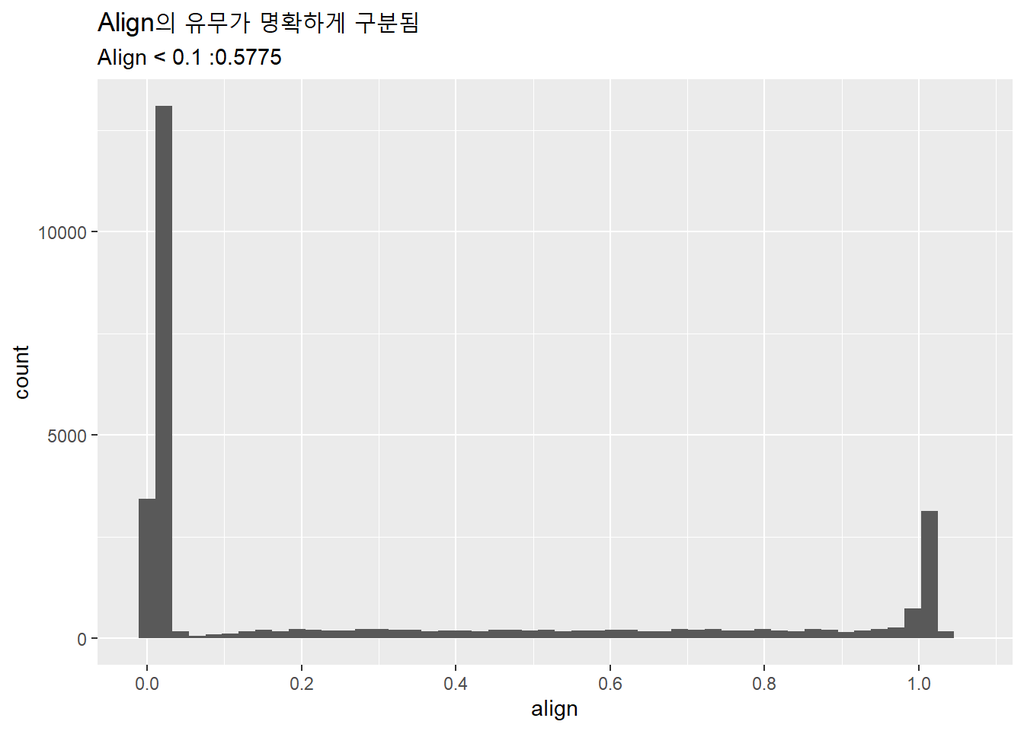

```r
ggplot(df) + geom_histogram(aes(x=align), bins=50) +
  scale_x_continuous(breaks=seq(0,1, 0.2)) +
  labs(title="Align의 유무가 명확하게 구분됨",
       subtitle=paste0("Align < 0.1 :", round(length(df[df$align < 0.1,]$length)/dim(df)[1], 4)))
```

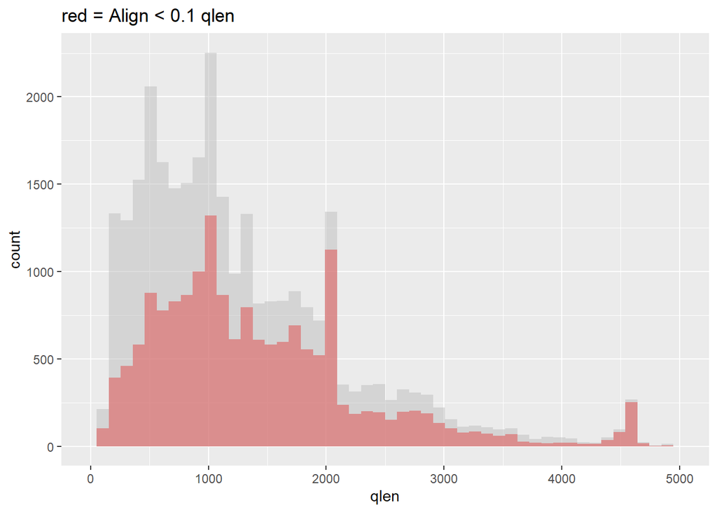

```r
ggplot(df) +
  geom_histogram(data=subset(df, align<0.1), aes(x=qlen), bins=50, fill='red', alpha=0.6) +
  geom_histogram(aes(x=qlen), bins=50, fill='gray', alpha=0.5) +
  scale_x_continuous(limits=c(0, 5000)) +
  labs(title="red = Align < 0.1 qlen")
```

```r
summary(df[df$align < 0.1,]$qlen)
```

```
##    Min. 1st Qu.  Median    Mean 3rd Qu.    Max.
##      35     789    1239    1442    1917    7386
```

```r
save_fasta <- function(df, save_path, column) {
  write.table(
    df[column], quote=FALSE, sep='\n', row.names=FALSE, col.names=FALSE, save_path
    )
}


df2 <- subset(df, align < 0.1) %>% select(qseqid, sseqid, qlen, qstart, seq) %>%
  pivot_wider(names_from = sseqid, values_from = qstart)

save_fasta(df=df2,
           column = c("qseqid", "seq"),
           save_path = "C:\\users\\user\\task\\barcode06\\analysis\\non_align.fasta")

save_fasta(df = subset(df2, qlen > 1500 & qlen < 2500),
           column=c("qseqid", "seq"),
           save_path = "C:\\users\\user\\task\\barcode06\\analysis\\non_align2k.fasta")
```

### Align > 0.9 기준 설정

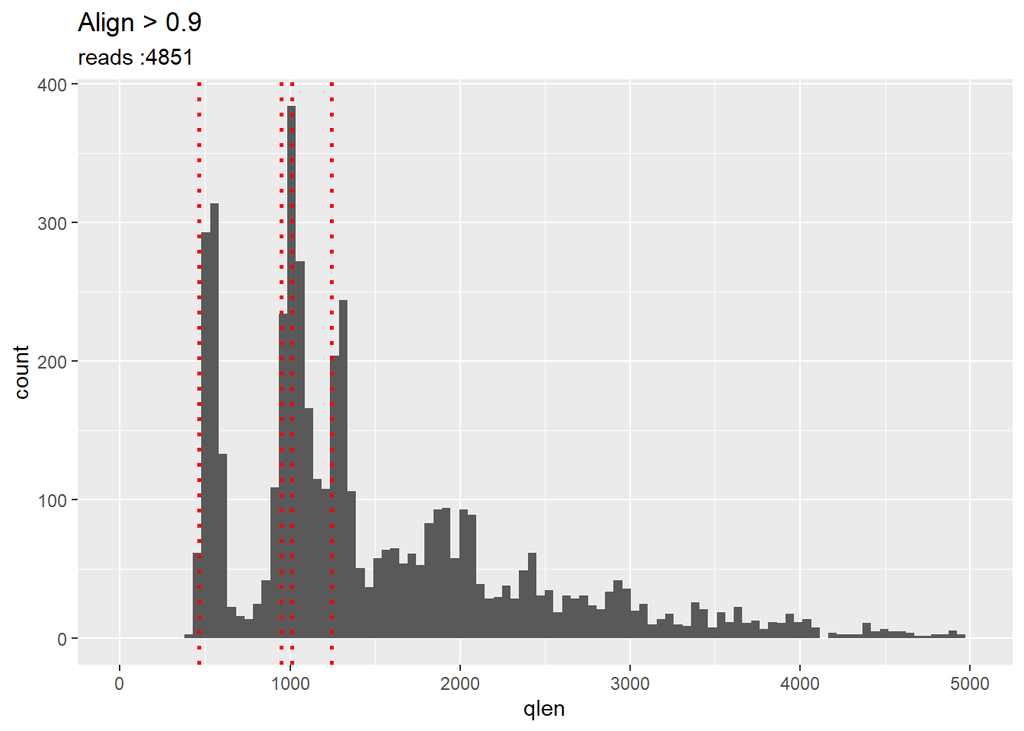

```r
ggplot(df) + geom_histogram(aes(x=qlen), subset(df, align > 0.9), bins=100) +
  scale_x_continuous(limits=c(0, 5000)) +
  geom_vline(xintercept=db_len, linetype='dotted', color='red', size=1) +
  labs(title = "Align > 0.9",
       subtitle=paste0("reads :", dim(subset(df, align > 0.9)[1]))
       )
```

- Align된 서열의 경우 각 CDS위치에 주도적으로 Pick이 존재함을 확인 하였음.

## Linkage CDS 확인

- Align된 read만 뽑음(df3)
- 각 Reference 별 Length등 통계량 확인

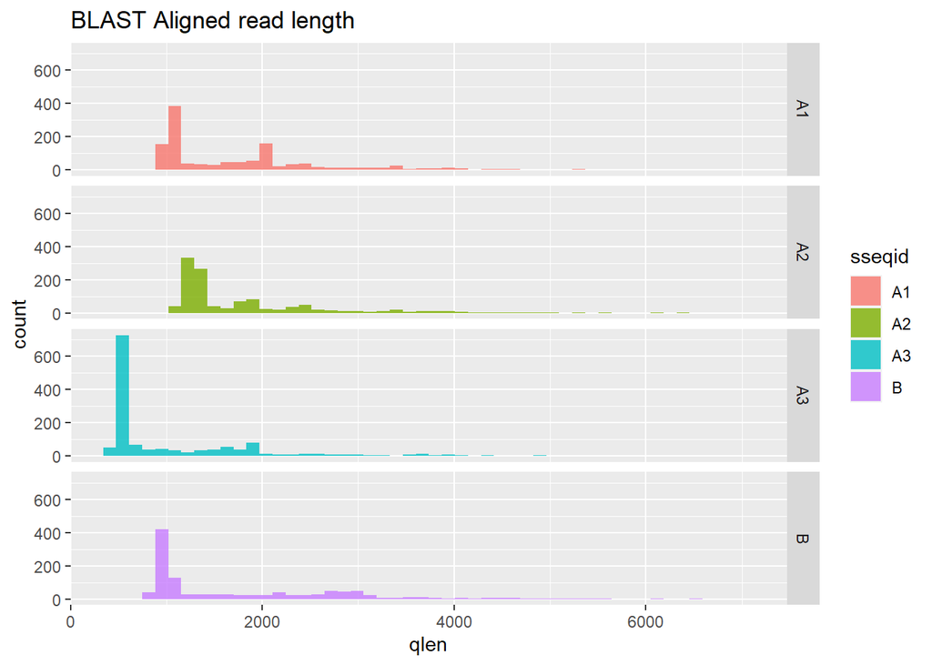

```r
ggplot(df) +
  geom_histogram(aes(x=qlen, fill=sseqid), subset(df, align > 0.9), bins=50, alpha=0.8) +
  labs(title = "BLAST Aligned read length") +
  facet_grid(sseqid~.)
```

```r
df3 <- subset(df, align > 0.9) %>% select(qseqid, sseqid, qlen, qstart, seq) %>%
  pivot_wider(names_from = sseqid, values_from = qstart)

rm(df)
```

- 단일 CDS(작은 length의 pick)가 주도적이며 더 긴 길이의 Pick도 미세하게 관측됨.

##### 하나의 CDS에만 align되고, 나머지는 Align되지 않은 경우

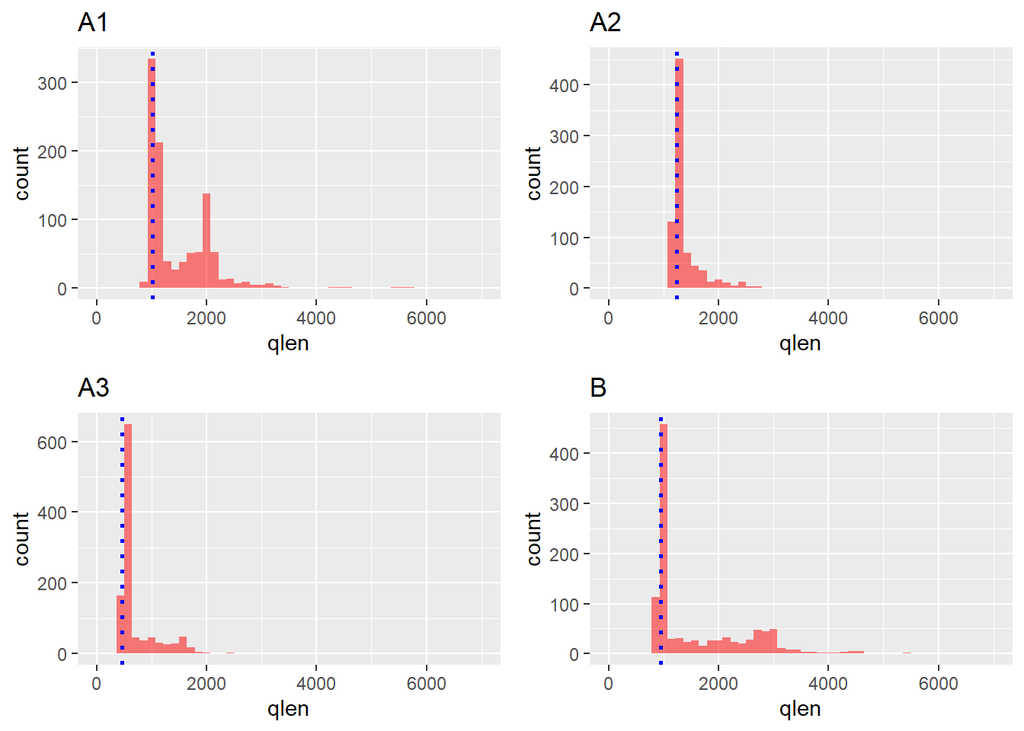

```r
f1 <- ggplot(df3) +
  geom_histogram(aes(x=qlen),
                 subset(df3, !is.na(A1) & is.na(A2) & is.na(A3) & is.na(B)),
                 bins=50, fill='red', alpha=0.5) +
  geom_vline(xintercept=db_len[1], linetype='dotted', color='blue', size=1) +
  scale_x_continuous(limits=c(0, 7000)) +
  labs(title="A1")
f2 <- ggplot(df3) +
  geom_histogram(aes(x=qlen),
                 subset(df3, is.na(A1) & !is.na(A2) & is.na(A3) & is.na(B)),
                 bins=50, fill='red', alpha=0.5) +
  geom_vline(xintercept=db_len[2], linetype='dotted', color='blue', size=1) +
  scale_x_continuous(limits=c(0, 7000)) +
  labs(title="A2")
f3 <- ggplot(df3) +
  geom_histogram(aes(x=qlen),
                 subset(df3, is.na(A1) & is.na(A2) & !is.na(A3) & is.na(B)),
                 bins=50, fill='red', alpha=0.5) +
  geom_vline(xintercept=db_len[3], linetype='dotted', color='blue', size=1) +
  scale_x_continuous(limits=c(0, 7000)) +
  labs(title="A3")
f4 <- ggplot(df3) +
  geom_histogram(aes(x=qlen),
                 subset(df3, is.na(A1) & is.na(A2) & is.na(A3) & !is.na(B)),
                 bins=50, fill='red', alpha=0.5) +
  geom_vline(xintercept=db_len[4], linetype='dotted', color='blue', size=1) +
  scale_x_continuous(limits=c(0, 7000)) +
  labs(title="B")

grid.arrange(f1, f2, f3, f4)
```

- A1의 경우 2k에 Pick이 나타남(위에서 확인한 2k픽과 유사할 것으로 추정)

##### 여러개의 CDS에 Align된 경우

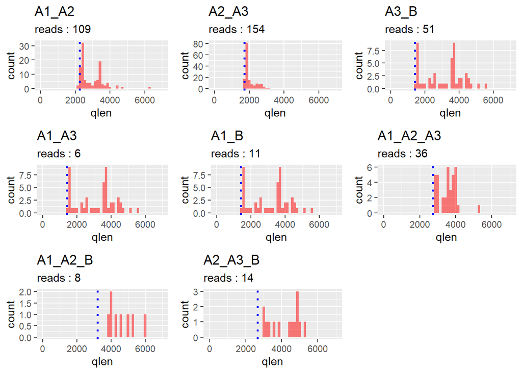

```r
#------------------------------------

p1 <- ggplot(df3) +
  geom_histogram(aes(x=qlen),
                 subset(df3, !is.na(A1) & !is.na(A2) & is.na(A3) & is.na(B)),
                 bins=50, fill='red', alpha=0.5) +
  geom_vline(xintercept=db_len[1]+db_len[2], linetype='dotted', color='blue', size=1) +
  scale_x_continuous(limits=c(0, 7000)) +
  labs(title="A1_A2",
       subtitle=paste0("reads : ",
         dim(subset(df3, !is.na(A1) & !is.na(A2) & is.na(A3) & is.na(B)))[1])
  )

p2 <- ggplot(df3) +
  geom_histogram(aes(x=qlen),
                 subset(df3, is.na(A1) & !is.na(A2) & !is.na(A3) & is.na(B)),
                 bins=50, fill='red', alpha=0.5) +
  geom_vline(xintercept=db_len[2]+db_len[3], linetype='dotted', color='blue', size=1) +
  scale_x_continuous(limits=c(0, 7000)) +
  labs(title="A2_A3",
       subtitle=paste0("reads : ",
         dim(
           subset(df3, is.na(A1) & !is.na(A2) & !is.na(A3) & is.na(B)))[1]
         )
  )

p3 <- ggplot(df3) +
  geom_histogram(aes(x=qlen),
                 subset(df3, is.na(A1) & is.na(A2) & !is.na(A3) & !is.na(B)),
                 bins=50, fill='red', alpha=0.5) +
  geom_vline(xintercept=db_len[3]+db_len[4], linetype='dotted', color='blue', size=1) +
  scale_x_continuous(limits=c(0, 7000)) +
  labs(title="A3_B",
       subtitle=paste0("reads : ",
         dim(
           subset(df3, is.na(A1) & is.na(A2) & !is.na(A3) & !is.na(B)))[1]
         )
  )

p4 <- ggplot(df3) +
  geom_histogram(aes(x=qlen),
                 subset(df3, is.na(A1) & is.na(A2) & !is.na(A3) & !is.na(B)),
                 bins=50, fill='red', alpha=0.5) +
  geom_vline(xintercept=db_len[3]+db_len[4], linetype='dotted', color='blue', size=1) +
  scale_x_continuous(limits=c(0, 7000)) +
  labs(title="A1_A3",
       subtitle=paste0("reads : ",
         dim(
           subset(df3, !is.na(A1) & is.na(A2) & !is.na(A3) & is.na(B)))[1]
         )
  )

p5 <- ggplot(df3) +
  geom_histogram(aes(x=qlen),
                 subset(df3, is.na(A1) & is.na(A2) & !is.na(A3) & !is.na(B)),
                 bins=50, fill='red', alpha=0.5) +
  geom_vline(xintercept=db_len[3]+db_len[4], linetype='dotted', color='blue', size=1) +
  scale_x_continuous(limits=c(0, 7000)) +
  labs(title="A1_B",
       subtitle=paste0("reads : ",
         dim(
           subset(df3, !is.na(A1) & is.na(A2) & is.na(A3) & !is.na(B)))[1]
         )
  )

p6 <- ggplot(df3) +
  geom_histogram(aes(x=qlen),
                 subset(df3, !is.na(A1) & !is.na(A2) & !is.na(A3) & is.na(B)),
                 bins=50, fill='red', alpha=0.5) +
  geom_vline(xintercept=db_len[1]+db_len[2]+db_len[3], linetype='dotted', color='blue', size=1) +
  scale_x_continuous(limits=c(0, 7000)) +
  labs(title="A1_A2_A3",
       subtitle=paste0("reads : ",
         dim(
           subset(df3, !is.na(A1) & !is.na(A2) & !is.na(A3) & is.na(B)))[1]
         )
  )

p7 <- ggplot(df3) +
  geom_histogram(aes(x=qlen),
                 subset(df3, !is.na(A1) & !is.na(A2) & is.na(A3) & !is.na(B)),
                 bins=50, fill='red', alpha=0.5) +
  geom_vline(xintercept=db_len[1]+db_len[2]+db_len[4], linetype='dotted', color='blue', size=1) +
  scale_x_continuous(limits=c(0, 7000)) +
  labs(title="A1_A2_B",
       subtitle=paste0("reads : ",
         dim(
           subset(df3, !is.na(A1) & !is.na(A2) & is.na(A3) & !is.na(B)))[1]
         )
  )

p8 <- ggplot(df3) +
  geom_histogram(aes(x=qlen),
                 subset(df3, is.na(A1) & !is.na(A2) & !is.na(A3) & !is.na(B)),
                 bins=50, fill='red', alpha=0.5) +
  geom_vline(xintercept=db_len[2]+db_len[3]+db_len[4], linetype='dotted', color='blue', size=1) +
  scale_x_continuous(limits=c(0, 7000)) +
  labs(title="A2_A3_B",
       subtitle=paste0("reads : ",
         dim(
           subset(df3, is.na(A1) & !is.na(A2) & !is.na(A3) & !is.na(B)))[1]
         )
  )
grid.arrange(p1,p2,p3,p4,p5,p6,p7,p8)
```

##### 여러개의 CDS에 Align된 서열 뽑아내기.

```r
save_fasta(df=subset(df3, !is.na(A1) & is.na(A2) & is.na(A3) & is.na(B)),
           column = c("qseqid", "seq"),
           save_path = "C:\\users\\user\\task\\barcode06\\analysis\\A1.fasta")

save_fasta(df=subset(df3, is.na(A1) & !is.na(A2) & is.na(A3) & is.na(B)),
           column = c("qseqid", "seq"),
           save_path = "C:\\users\\user\\task\\barcode06\\analysis\\A2.fasta")

save_fasta(df=subset(df3, is.na(A1) & !is.na(A2) & !is.na(A3) & is.na(B)),
           column = c("qseqid", "seq"),
           save_path = "C:\\users\\user\\task\\barcode06\\analysis\\A3.fasta")

save_fasta(df=subset(df3, is.na(A1) & is.na(A2) & is.na(A3) & !is.na(B)),
           column = c("qseqid", "seq"),
           save_path = "C:\\users\\user\\task\\barcode06\\analysis\\B.fasta")

##----
save_fasta(df=subset(df3, !is.na(A1) & !is.na(A2) & is.na(A3) & is.na(B)),
           column = c("qseqid", "seq"),
           save_path = "C:\\users\\user\\task\\barcode06\\analysis\\A1_A2.fasta")

save_fasta(df=subset(df3, is.na(A1) & !is.na(A2) & !is.na(A3) & is.na(B)),
           column = c("qseqid", "seq"),
           save_path = "C:\\users\\user\\task\\barcode06\\analysis\\A2_A3.fasta")

save_fasta(df=subset(df3, is.na(A1) & is.na(A2) & !is.na(A3) & !is.na(B)),
           column = c("qseqid", "seq"),
           save_path = "C:\\users\\user\\task\\barcode06\\analysis\\A3_B.fasta")

save_fasta(df=subset(df3, !is.na(A1) & !is.na(A2) & !is.na(A3) & is.na(B)),
           column = c("qseqid", "seq"),
           save_path = "C:\\users\\user\\task\\barcode06\\analysis\\A1_A2_A3.fasta")

save_fasta(df=subset(df3, is.na(A1) & !is.na(A2) & !is.na(A3) & !is.na(B)),
           column = c("qseqid", "seq"),
           save_path = "C:\\users\\user\\task\\barcode06\\analysis\\A2_A3_B.fasta")

save_fasta(df=subset(df3, is.na(A1) & !is.na(A2) & !is.na(A3) & is.na(B)),
           column = c("qseqid", "seq"),
           save_path = "C:\\users\\user\\task\\barcode06\\analysis\\A2_A3.fasta")
```